# Reproducible Research Course Project 1

```r
library(tidyverse)
library(glue)
library(magrittr)
setwd("//chws3092/PPM Admin File/Pricing Product General/Users/Carey C/Coursera/Reproducible Research")
activity <- read.csv("data/activity.csv", stringsAsFactors = FALSE)
```

## Including Plots

Let’s examine the distribution of step values by plotting a histogram:

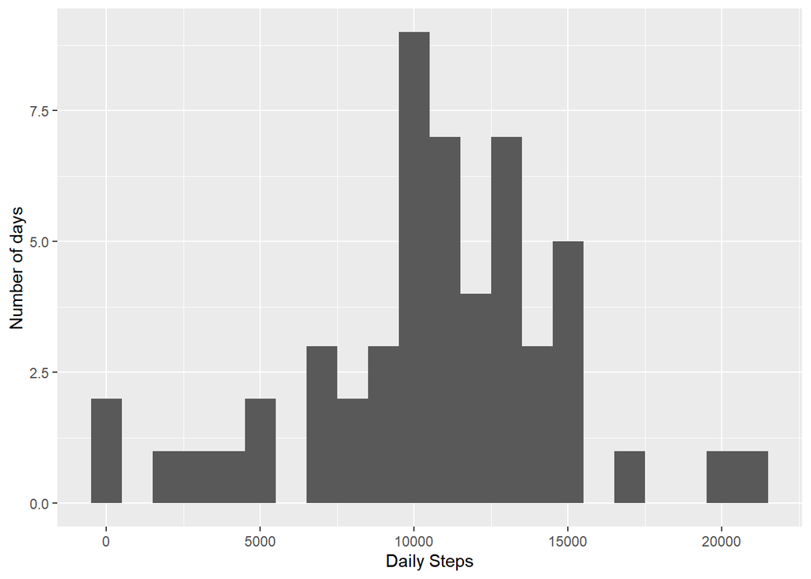

```r
steps_per_day <- activity %>%
  filter(!is.na(steps)) %>%
  group_by(date) %>%
  summarise(steps = sum(steps))

ggplot(steps_per_day) +
  geom_histogram(aes(steps), binwidth = 1000) +
  labs(x = "Daily Steps", y = "Number of days")
```

Now the mean and median steps per day:

```r
mean <- mean(steps_per_day$steps) %>% round()
median <- median(steps_per_day$steps)
print(str_glue("Mean steps per day: {mean}"))
```

```
## Mean steps per day: 10766
```

```r
print(str_glue("Median steps per day: {median}"))
```

```
## Median steps per day: 10765
```

Let’s look at a time series plot of the steps per 5 minute interval next:

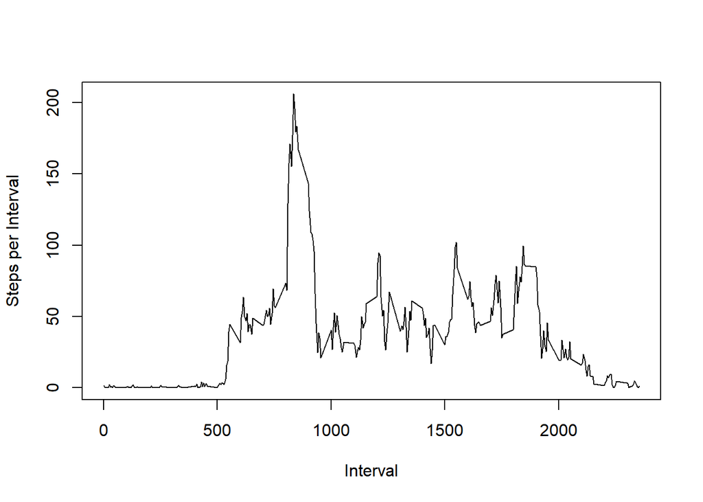

```r
steps_per_interval <- activity %>%
  filter(!is.na(steps)) %>%
  group_by(interval) %>%
  summarise(steps = mean(steps))
plot(steps_per_interval$interval,
     steps_per_interval$steps,
     type = "l",
     xlab = "Interval",
     ylab = "Steps per Interval")
```

```r
max_val <- which.max(steps_per_interval$steps)
print(str_glue("Interval with maximum steps is {steps_per_interval[max_val, 'interval']}, which contains {steps_per_interval[max_val, 'steps'] %>% round()} steps."))
```

```
## Interval with maximum steps is 835, which contains 206 steps.
```

Next, let’s calculate the number of missing values in the dataset.

```r
no_missing <- activity %>% filter(is.na(steps)) %>% count()
print(str_glue("There are {no_missing} missing values in the dataset."))
```

```
## There are 2304 missing values in the dataset.
```

We are going to fill in these missing values with the mean value for that interval in all the days. We do so as follows:

```r
new_activity <- activity %>%
  left_join(steps_per_interval, by = "interval") %>%
  mutate(steps = coalesce(steps.x, as.integer(round(steps.y)))) %>%
  select(-steps.x, -steps.y)
```

Now we make a histogram and compute the mean and median of the values of steps per day.

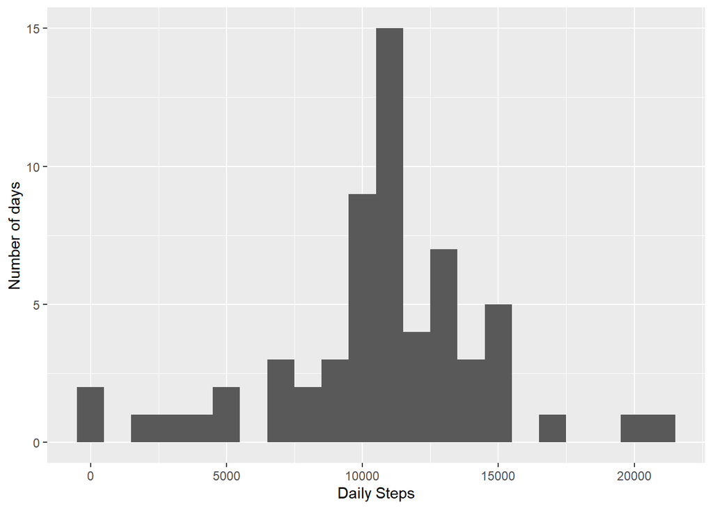

```r
new_steps_per_day <- new_activity %>%
  group_by(date) %>%
  summarise(steps = sum(steps))

ggplot(new_steps_per_day) +
  geom_histogram(aes(steps), binwidth = 1000) +
  labs(x = "Daily Steps", y = "Number of days")
```

```r
mean <- mean(new_steps_per_day$steps) %>% round()
median <- median(new_steps_per_day$steps)
print(str_glue("Mean steps per day: {mean}"))
```

```
## Mean steps per day: 10766
```

```r
print(str_glue("Median steps per day: {median}"))
```

```
## Median steps per day: 10762
```

Finally, let’s examine the differences in activity patterns between weekdays and weekends.

```r
activity_with_factors <- new_activity %>%
  mutate(weekday = weekdays(as.Date(date))) %>%
  mutate(weekday = ifelse(weekday %in% c("Monday", "Tuesday", "Wednesday", "Thrusday", "Friday"),
                          "weekday",
                          "weekend")) %>%
  mutate(weekday = as.factor(weekday))
```

And here’s a panel plot produced to show the activity patterns on a weekday vs a weekend.

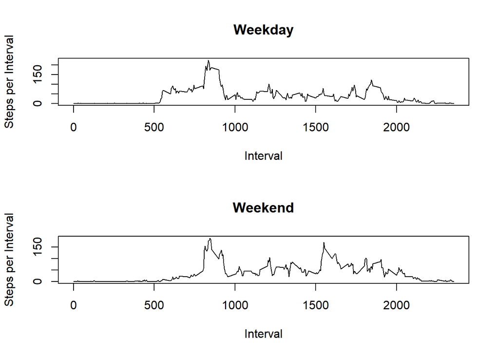

```r
plot_data <- activity_with_factors %>%
  group_by(interval, weekday) %>%
  summarise(steps = mean(steps))
plot_data_weekday <- plot_data %>% filter(weekday == "weekday")
plot_data_weekend <- plot_data %>% filter(weekday == "weekend")

par(mfrow = c(2, 1))
plot(plot_data_weekday$interval,
     plot_data_weekday$steps,
     type = "l",
     xlab = "Interval",
     ylab = "Steps per Interval",
     main = "Weekday")

plot(plot_data_weekend$interval,
     plot_data_weekend$steps,
     type = "l",
     xlab = "Interval",
     ylab = "Steps per Interval",
     main = "Weekend")
```